# Culture Media Analysis

Michael Whitehouse

2026-03-04

## Embryo Culture Outcomes

- fresh autologous IVF and EMBRYO BANKING attempts in the KindEMR
- GM-CSF media used for cycles where the “Golds Media” procedure was documented
- Global media used at Lindbergh prior to 2024-08-02, at West Loop prior to 2025-01-01
- Irvine media used otherwise
- compare Global vs. Irvine media outcomes at Lindbergh and West Loop labs, excluding other media and labs
- compare fertilization rates, usable blastocyst rates (Gardner grade 3BB or better by Day 6, or 4BB by Day 7), and euploidy rates
- adjust for oocyte age and other relevant covariates
- GEE logistict regression clustering at patient level to account for multiple cycles per patient and within-patient correlation
- adjust for non-linear effects of age both by SART age group and splines for comparison

## Transfer Outcomes

- autologous euploid single embryo transfers (SETs) of embryos cultured in each respective culture media
- exclude transfers too recent to have outcome data, as with KPI queries
  - include_in_bhcg_outcomes = TRUE for chemical pregnancy rate
  - include_in_sac_fh_outcomes = TRUE for clinical pregnancy rate

## Load Processed Data

```r
# Define paths (project_dir already set in load-libraries chunk)
scripts_dir <- fs::path(project_dir, "scripts")

refresh_query <- FALSE
write_data_files <- FALSE
source(fs::path(scripts_dir, "process_raw_data.R"))

kpis_ivf <- kpis |>
  filter(include_kpi_ivf_cycles) |>
  filter(d1_culture_media %in% c("Global", "Irvine"), lab_location %in% c("Lindbergh", "West Loop")) |>
  drop_na(d1_culture_media)

kpis_fet <- kpis |>
  filter(include_kpi_single_autologous_euploid_fet) |>
  drop_na(transferred_embryos_d1_culture_media) |>
  filter(lab_location %in% c("Lindbergh", "West Loop")) |>
  mutate(
    day_number = as.factor(transferred_embryos_developmental_day_min),
    # extract elements of gardner grades e.g. "4AA" -> expansion = 4, icm_grade = A, troph_grade = A
    expansion = str_extract(transferred_blastocyst_grade_at_cryo, "\\d+"),
    icm_grade = str_extract(transferred_blastocyst_grade_at_cryo, "[A-C](?=$|[A-C])"),
    troph_grade = str_extract(transferred_blastocyst_grade_at_cryo, "[A-C]$")
  ) |>
  filter(expansion >= 3) # restrict to transfers of blastocysts with at least expansion 3, as these are the ones considered "usable" in the culture outcomes analyses
```

## Data Overview

```r
cat(summarize_cycles(kpis_ivf, "Fresh Autologous IVF attempts"))
```

#### Fresh Autologous IVF attempts

- **3,456** cycles
- **1,810** patients
- **2** clinics
- Date range: **September 18, 2023** to **February 21, 2026**

```r
cat(summarize_cycles(kpis_fet, "Autologous Single Euploid Embryo FET attempts"))
```

#### Autologous Single Euploid Embryo FET attempts

- **929** cycles
- **686** patients
- **2** clinics
- Date range: **March 14, 2024** to **February 19, 2026**

## Culture Outcomes

```r
t1_data <- kpis_ivf |>
  select(
    d1_culture_media, age, bmi, protocol,
      starts_with("attempt_diagnosis"),
    eggs_retrieved, d0_hyaled, d0_icsi, d1_icsi_2pn,
    d1_2pn_ongoing_to_d5, total_blasts,
    usable_blasts,
    embryos_biopsied, pgta_euploid
  ) |>
  mutate_at(vars(eggs_retrieved, d0_hyaled, d0_icsi, d1_icsi_2pn, d1_2pn_ongoing_to_d5, total_blasts, usable_blasts, embryos_biopsied, pgta_euploid), as.integer) |>
  auto_label()

t1_main <- t1_data |>
  tbl_summary(by = d1_culture_media) |>
  add_p(test = list(
    all_categorical() ~ "chisq.test",
    all_continuous() ~ "wilcox.test"
  )) |>
  add_overall() |>
  modify_spanning_header(c(stat_1, stat_2) ~ "**Culture Media**") |>
  bold_labels()

# ---------------------------------------------------------
# 2. HELPER FUNCTION TO CALCULATE COUNTS, RATES, CIs, & P-VALUES
# ---------------------------------------------------------
calc_rate_row <- function(df, metric_name, num_var, den_var) {
  # Helper to format string as: n/N (Rate%) [95% CI]
  get_ci_string <- function(x, n) {
    if (is.na(n) || n == 0) {
      return("NA")
    }
    test <- prop.test(x, n)
    est <- test$estimate * 100
    ci_lower <- test$conf.int[1] * 100
    ci_upper <- test$conf.int[2] * 100

    # %d formats the integer count, %.1f formats the decimal
    sprintf("%d/%d (%.1f%%) [%.1f%%, %.1f%%]", x, n, est, ci_lower, ci_upper)
  }

  # 1. Overall Stats
  tot_num <- sum(df[[num_var]], na.rm = TRUE)
  tot_den <- sum(df[[den_var]], na.rm = TRUE)
  stat_0 <- get_ci_string(tot_num, tot_den)

  # 2. Grouped Stats (Alphabetical: stat_1 = Global, stat_2 = Irvine)
  df_grp <- df |>
    group_by(d1_culture_media) |>
    summarize(
      x = sum(.data[[num_var]], na.rm = TRUE),
      n = sum(.data[[den_var]], na.rm = TRUE),
      .groups = "drop"
    ) |>
    arrange(d1_culture_media) # Ensure Global is first, Irvine is second

  stat_1 <- get_ci_string(df_grp$x[1], df_grp$n[1])
  stat_2 <- get_ci_string(df_grp$x[2], df_grp$n[2])

  # 3. P-value (2-proportion Z-test comparing Global vs Irvine)
  pval <- NA_real_
  if (all(df_grp$n > 0)) {
    ptest <- prop.test(df_grp$x, df_grp$n)
    pval <- ptest$p.value
  }

  # Return formatted row for gtsummary
  tibble(
    label = metric_name,
    stat_0 = stat_0,
    stat_1 = stat_1,
    stat_2 = stat_2,
    p.value = pval,
    row_type = "label",
    var_type = "continuous",
    variable = metric_name
  )
}

# ---------------------------------------------------------
# 3. GENERATE THE NEW ROWS FOR POOLED RATES
# ---------------------------------------------------------
rate_rows <- bind_rows(
  calc_rate_row(t1_data, "Maturity Rate (Pooled)", "d0_icsi", "d0_hyaled"),
  calc_rate_row(t1_data, "Fertilization Rate (Pooled)", "d1_icsi_2pn", "d0_icsi"),
  calc_rate_row(t1_data, "Blastulation Rate (Pooled)", "d1_2pn_ongoing_to_d5", "d1_icsi_2pn"),
  calc_rate_row(t1_data, "Usable Blast Rate (Pooled)", "usable_blasts", "d1_icsi_2pn"),
  calc_rate_row(t1_data, "Euploidy Rate (Pooled)", "pgta_euploid", "embryos_biopsied")
)

# ---------------------------------------------------------
# 4. INJECT ROWS INTO GTSUMMARY TABLE
# ---------------------------------------------------------
final_table <- t1_main |>
  modify_table_body(~ bind_rows(.x, rate_rows)) |>
  # Update footnotes to clearly explain the new rich formatting
  modify_footnote(
    all_stat_cols() ~ "Patient-level counts: Median [IQR]; Pooled rates: n/N (%) [95% CI]"
  ) |>
  modify_caption("**Table 1. Cycle Characteristics and Pooled Clinical Outcomes by Culture Media**")

# Print the final combined table
final_table
```

**Table 1. Cycle Characteristics and Pooled Clinical Outcomes by Culture Media**

| **Characteristic** | **Overall** N = 3,456<sup>1</sup> | **Culture Media** **Global** N = 910<sup>1</sup> | **Culture Media** **Irvine** N = 2,546<sup>1</sup> | **p-value**<sup>2</sup> |  |
| --- | --- | --- | --- | --- | --- |
| Age | 37.2 (33.8, 41.0) | 36.9 (33.9, 40.8) | 37.3 (33.8, 41.1) |  | 0.7 |
| Unknown | 1 | 1 | 0 |  |  |
| BMI | 28 (24, 34) | 28 (24, 35) | 28 (24, 33) | 0.2 |  |
| Unknown | 66 | 47 | 19 |  |  |
| Protocol |  |  |  | <0.001 |  |
| Antagonist | 1,883 (55%) | 510 (57%) | 1,373 (54%) |  |  |
| Antagonist ( NPR) | 879 (26%) | 197 (22%) | 682 (27%) |  |  |
| Dual trigger/Antag | 2 (<0.1%) | 2 (0.2%) | 0 (0%) |  |  |
| E2 Priming | 70 (2.0%) | 9 (1.0%) | 61 (2.4%) |  |  |
| Long Agonist | 31 (0.9%) | 4 (0.4%) | 27 (1.1%) |  |  |
| Lupron Downregulation | 49 (1.4%) | 23 (2.5%) | 26 (1.0%) |  |  |
| Luteal Start | 1 (<0.1%) | 1 (0.1%) | 0 (0%) |  |  |
| Microdose Flare | 81 (2.4%) | 28 (3.1%) | 53 (2.1%) |  |  |
| Microflare Lupron | 125 (3.6%) | 73 (8.1%) | 52 (2.1%) |  |  |
| Mini Stim | 48 (1.4%) | 5 (0.6%) | 43 (1.7%) |  |  |
| Modified Low Dose Flare* | 238 (6.9%) | 48 (5.3%) | 190 (7.5%) |  |  |
| Standard Flare | 27 (0.8%) | 2 (0.2%) | 25 (1.0%) |  |  |
| Unknown | 22 | 8 | 14 |  |  |
| Attempt Diagnosis Male Factor | 643 (19%) | 143 (17%) | 500 (20%) | 0.075 |  |
| Unknown | 68 | 61 | 7 |  |  |
| Attempt Diagnosis Tubal Factor | 271 (8.0%) | 63 (7.4%) | 208 (8.2%) | 0.5 |  |
| Unknown | 68 | 61 | 7 |  |  |
| Attempt Diagnosis Uterine Factor | 58 (1.7%) | 14 (1.6%) | 44 (1.7%) | >0.9 |  |
| Unknown | 68 | 61 | 7 |  |  |
| Attempt Diagnosis Ovulation Disorder | 1,919 (57%) | 536 (63%) | 1,383 (54%) | <0.001 |  |
| Unknown | 68 | 61 | 7 |  |  |
| Attempt Diagnosis Pcos | 351 (10%) | 92 (11%) | 259 (10%) | 0.6 |  |
| Unknown | 68 | 61 | 7 |  |  |
| Attempt Diagnosis Fha | 3 (<0.1%) | 1 (0.1%) | 2 (<0.1%) | >0.9 |  |
| Unknown | 68 | 61 | 7 |  |  |
| Attempt Diagnosis Dor | 1,470 (43%) | 409 (48%) | 1,061 (42%) | 0.001 |  |
| Unknown | 68 | 61 | 7 |  |  |
| Attempt Diagnosis Other Ovulation Disorder | 100 (3.0%) | 36 (4.2%) | 64 (2.5%) | 0.014 |  |
| Unknown | 68 | 61 | 7 |  |  |
| Attempt Diagnosis Gestational Carrier | 23 (0.7%) | 6 (0.7%) | 17 (0.7%) | >0.9 |  |
| Unknown | 68 | 61 | 7 |  |  |
| Attempt Diagnosis Freeze all | 117 (3.5%) | 12 (1.4%) | 105 (4.1%) | <0.001 |  |
| Unknown | 68 | 61 | 7 |  |  |
| Attempt Diagnosis Recurrent Pregnancy Loss | 169 (5.0%) | 35 (4.1%) | 134 (5.3%) | 0.2 |  |
| Unknown | 68 | 61 | 7 |  |  |
| Attempt Diagnosis PGT | 155 (4.6%) | 36 (4.2%) | 119 (4.7%) | 0.7 |  |
| Unknown | 68 | 61 | 7 |  |  |
| Attempt Diagnosis Unexplained Infertility | 311 (9.2%) | 76 (9.0%) | 235 (9.3%) | 0.8 |  |
| Unknown | 68 | 61 | 7 |  |  |
| Attempt Diagnosis Other Non Infertile | 187 (5.5%) | 42 (4.9%) | 145 (5.7%) | 0.4 |  |
| Unknown | 68 | 61 | 7 |  |  |
| Eggs Retrieved | 11 (6, 19) | 11 (6, 19) | 12 (6, 20) | 0.6 |  |
| Day 0 Hyaled | 11 (6, 19) | 11 (6, 19) | 11 (5, 19) | 0.6 |  |
| Day 0 ICSI | 8 (4, 14) | 8 (4, 13) | 8 (4, 15) | 0.2 |  |
| Day 1 ICSI 2pn | 6 (3, 11) | 5 (2, 10) | 6 (3, 11) | 0.067 |  |
| Day 1 2pn Ongoing to D5 | 5 (2, 11) | 5 (2, 10) | 6 (2, 11) | 0.13 |  |
| Total Blasts | 3 (1, 6) | 3 (1, 6) | 3 (1, 6) | >0.9 |  |
| Usable Blasts | 2 (0, 4) | 2 (0, 4) | 2 (0, 4) | 0.4 |  |
| Embryos Biopsied | 1 (0, 3) | 1 (0, 3) | 1 (0, 4) | 0.13 |  |
| PGT-a Euploid | 1 (0, 3) | 1 (0, 3) | 1 (0, 3) | 0.5 |  |
| Unknown | 1,505 | 417 | 1,088 |  |  |
| Maturity Rate (Pooled) | 34930/47254 (73.9%) [73.5%, 74.3%] | 8808/12190 (72.3%) [71.5%, 73.0%] | 26122/35064 (74.5%) [74.0%, 75.0%] | <0.001 |  |
| Fertilization Rate (Pooled) | 25934/34930 (74.2%) [73.8%, 74.7%] | 6550/8808 (74.4%) [73.4%, 75.3%] | 19384/26122 (74.2%) [73.7%, 74.7%] | 0.8 |  |
| Blastulation Rate (Pooled) | 25438/25934 (98.1%) [97.9%, 98.2%] | 6443/6550 (98.4%) [98.0%, 98.7%] | 18995/19384 (98.0%) [97.8%, 98.2%] | 0.064 |  |
| Usable Blast Rate (Pooled) | 10277/25934 (39.6%) [39.0%, 40.2%] | 2704/6550 (41.3%) [40.1%, 42.5%] | 7573/19384 (39.1%) [38.4%, 39.8%] | 0.002 |  |
| Euploidy Rate (Pooled) | 3807/7928 (48.0%) [46.9%, 49.1%] | 946/2057 (46.0%) [43.8%, 48.2%] | 2861/5871 (48.7%) [47.4%, 50.0%] | 0.034 |  |

<sup>1</sup> Patient-level counts: Median [IQR]; Pooled rates: n/N (%) [95% CI]  
<sup>2</sup> Wilcoxon rank sum test; Pearson’s Chi-squared test

#### Usable Blast Rate by Age and Culture Media

[figure not shown]

Figure 1. Usable blast rate by age and culture media (pooled usable blasts / pooled 2PNs).

```r
usable_rate_plot_data <- kpis_ivf |>
  transmute(
    d1_culture_media,
    age = as.numeric(age),
    n_2pn = as.integer(d1_icsi_2pn_ongoing_to_d5),
    usable_blasts = as.integer(usable_blasts_d1_icsi_2pn)
  ) |>
  filter(!is.na(age), !is.na(n_2pn), n_2pn > 0, !is.na(usable_blasts)) |>
  mutate(
    usable_blasts = pmax(0L, pmin(usable_blasts, n_2pn)),
    age_year = floor(age)
  ) |>
  group_by(d1_culture_media, age_year) |>
  summarize(
    n_2pn = sum(n_2pn, na.rm = TRUE),
    usable_blasts = sum(usable_blasts, na.rm = TRUE),
    .groups = "drop"
  ) |>
  mutate(
    usable_blast_rate = usable_blasts / n_2pn
  )

plot1 <- ggplot(usable_rate_plot_data, aes(x = age_year, y = usable_blast_rate, color = d1_culture_media, group = d1_culture_media)) +
  geom_line(linewidth = 1.1) +
  geom_point(aes(size = n_2pn), alpha = 0.8) +
  scale_y_continuous(labels = scales::percent_format(accuracy = 1), limits = c(0, 1)) +
  scale_x_continuous(breaks = scales::pretty_breaks()) +
  scale_size_continuous(name = "Pooled 2PNs (N)") +
  labs(
    title = "Usable Blast Rate by Age and Culture Media",
    subtitle = "Total usable blasts divided by total 2PNs",
    x = "Age (binned by year)",
    y = "Usable blast rate",
    color = "Culture media"
  )

add_kb_logo(plot1)
```

#### Euploid Rate by Age and Culture Media

[figure not shown]

Figure 2. Euploid rate by age and culture media (pooled euploid embryos / pooled biopsied embryos).

```r
euploid_rate_plot_data <- kpis_ivf |>
  filter(d1_culture_media %in% c("Global", "Irvine")) |>
  transmute(
    d1_culture_media,
    age = as.numeric(age),
    embryos_biopsied = as.integer(embryos_biopsied),
    pgta_euploid = as.integer(pgta_euploid)
  ) |>
  filter(!is.na(age), !is.na(embryos_biopsied), embryos_biopsied > 0, !is.na(pgta_euploid)) |>
  mutate(
    pgta_euploid = pmax(0L, pmin(pgta_euploid, embryos_biopsied)),
    age_year = floor(age)
  ) |>
  group_by(d1_culture_media, age_year) |>
  summarize(
    embryos_biopsied = sum(embryos_biopsied, na.rm = TRUE),
    pgta_euploid = sum(pgta_euploid, na.rm = TRUE),
    .groups = "drop"
  ) |>
  mutate(
    euploid_rate = pgta_euploid / embryos_biopsied
  )

plot2 <- ggplot(euploid_rate_plot_data, aes(x = age_year, y = euploid_rate, color = d1_culture_media, group = d1_culture_media)) +
  geom_line(linewidth = 1.1) +
  geom_point(aes(size = embryos_biopsied), alpha = 0.8) +
  scale_y_continuous(labels = scales::percent_format(accuracy = 1), limits = c(0, 1)) +
  scale_x_continuous(breaks = scales::pretty_breaks()) +
  scale_size_continuous(name = "Pooled Biopsied Embryos (N)") +
  labs(
    title = "Euploid Rate by Age and Culture Media",
    subtitle = "Total euploid embryos divided by total biopsied embryos",
    x = "Age (binned by year)",
    y = "Euploid rate",
    color = "Culture media"
  )

add_kb_logo(plot2)
```

## GEE Logistic Regression Models for Culture Outcomes

```r
# Prepare data in long format: one row per embryo
blast_data <- kpis_ivf |>
  select(patient_id, d1_culture_media, bmi, age, age_group, d1_icsi_2pn, d1_2pn_ongoing_to_d5) |>
  mutate(
    n_embryos = as.integer(d1_icsi_2pn),
    n_blasts = as.integer(d1_2pn_ongoing_to_d5),
    n_blasts = pmax(0L, pmin(n_blasts, n_embryos))
  ) |>
  filter(!is.na(patient_id)) |>
  filter(!is.na(d1_culture_media)) |>
  filter(!is.na(n_embryos) & n_embryos > 0) |>
  filter(!is.na(n_blasts)) |>
  mutate(cycle_row_id = row_number()) |>
  tidyr::uncount(weights = n_embryos) |>
  group_by(cycle_row_id) |>
  mutate(
    blast_outcome = as.integer(row_number() <= first(n_blasts))
  ) |>
  ungroup() |>
  mutate(
    d1_culture_media = factor(d1_culture_media),
    age_group = factor(age_group)
  )

# Keep only complete model rows
blast_model_data <- blast_data |>
  filter(!is.na(bmi), !is.na(age_group)) |>
  mutate(culture_media = d1_culture_media) |>
  droplevels() |>
  auto_label()

# Guardrails: stop early with useful diagnostics
if (nrow(blast_model_data) == 0) {
  stop("No rows available for model after filtering for non-missing BMI/oocyte_age_group.")
}
if (dplyr::n_distinct(blast_model_data$d1_culture_media) < 2) {
  stop("d1_culture_media has <2 levels in model data.")
}
if (dplyr::n_distinct(blast_model_data$age_group) < 2) {
  stop("oocyte_age_group has <2 levels in model data.")
}

# Fit GEE logistic regression
model <- geepack::geeglm(
  blast_outcome ~ culture_media + age_group,
  id = patient_id,
  data = blast_model_data,
  family = binomial,
  corstr = "exchangeable"
)

# Show model summary
tbl2 <- tbl_regression(model, exponentiate = TRUE) |>
  modify_caption("**Table 2. Adjusted Odds of Usable Blastocyst Formation by Culture Media (GEE Model)**") |>
  modify_footnote(
    estimate ~ "Outcome modeled is usable blastocyst formation (Gardner grade 3BB or better by Day 7). Population-averaged odds ratios from a logistic GEE model with exchangeable working correlation; embryos clustered within patient (id = patient_id) and robust (sandwich) standard errors used for within-patient correlation."
  )

print(tbl2)
```

| **Characteristic** | **OR**<sup>1</sup> | **95% CI** | **p-value** |
| --- | --- | --- | --- |
| Culture Media |  |  |  |
| Global | — | — |  |
| Irvine | 0.84 | 0.58, 1.21 | 0.3 |
| Age Group |  |  |  |
| <35 | — | — |  |
| 35-37 | 0.69 | 0.39, 1.21 | 0.2 |
| 38-40 | 0.33 | 0.20, 0.55 | <0.001 |
| 41-42 | 0.19 | 0.12, 0.31 | <0.001 |
| 43+ | 0.08 | 0.05, 0.13 | <0.001 |

Abbreviations: CI = Confidence Interval, OR = Odds Ratio  
<sup>1</sup> Outcome modeled is usable blastocyst formation (Gardner grade 3BB or better by Day 7). Population-averaged odds ratios from a logistic GEE model with exchangeable working correlation; embryos clustered within patient (id = patient_id) and robust (sandwich) standard errors used for within-patient correlation.

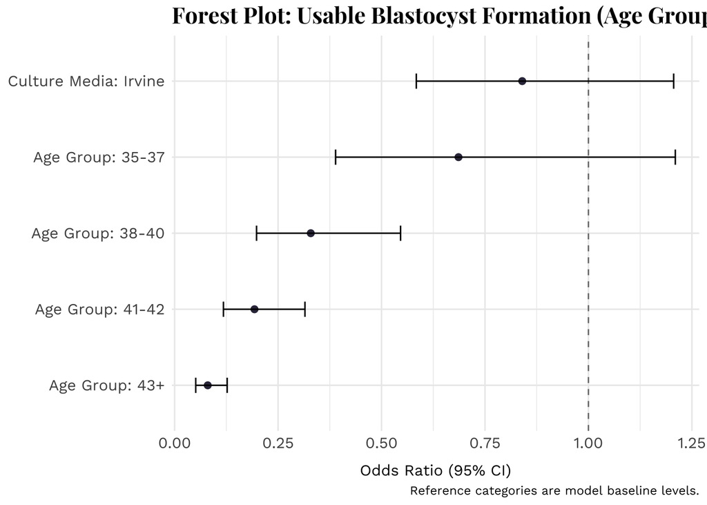

Figure 5. Forest plot of adjusted odds for usable blastocyst formation by culture media (age-group GEE model).

```r
plot_forest(model, title = "Forest Plot: Usable Blastocyst Formation (Age Group Model)", caption = "Reference categories are model baseline levels.")
```

```r
# Build explicit spline basis terms so they are displayed cleanly in tbl_regression
blast_model_data_spline <- blast_model_data |>
  mutate(
    age_spline = splines::ns(age, df = 4),
    age_spline_1 = age_spline[, 1],
    age_spline_2 = age_spline[, 2],
    age_spline_3 = age_spline[, 3],
    age_spline_4 = age_spline[, 4]
  ) |>
  select(-age_spline)

# Fit GEE logistic regression with continuous age, using splines to fit expected s-shaped curve
model_continuous_age <- geepack::geeglm(
  blast_outcome ~ culture_media + age_spline_1 + age_spline_2 + age_spline_3 + age_spline_4,
  id = patient_id,
  data = blast_model_data_spline,
  family = binomial,
  corstr = "exchangeable"
)

spline_term_labels <- list(
  age_spline_1 ~ "Age (non-linear term 1)",
  age_spline_2 ~ "Age (non-linear term 2)",
  age_spline_3 ~ "Age (non-linear term 3)",
  age_spline_4 ~ "Age (non-linear term 4)"
)

tbl3 <- tbl_regression(
  model_continuous_age,
  exponentiate = TRUE,
  include = c(culture_media, age_spline_1, age_spline_2, age_spline_3, age_spline_4),
  label = spline_term_labels
) |>
  modify_caption("**Table 3. Adjusted Odds of Usable Blastocysts by Culture Media (GEE Model; age treated as continuous using natural spline terms)**") |>
  modify_footnote(
    estimate ~ "Outcome modeled is usable blastocyst formation (Gardner grade 3BB or better by Day 7). Population-averaged odds ratios from a logistic GEE model with exchangeable working correlation; embryos clustered within patient (id = patient_id) and robust (sandwich) standard errors used for within-patient correlation."
  )

print(tbl3)
```

| **Characteristic** | **OR**<sup>1</sup> | **95% CI** | **p-value** |
| --- | --- | --- | --- |
| Culture Media |  |  |  |
| Global | — | — |  |
| Irvine | 0.84 | 0.59, 1.21 | 0.4 |
| Age (non-linear term 1) | 0.31 | 0.02, 5.32 | 0.4 |
| Age (non-linear term 2) | 0.13 | 0.02, 0.75 | 0.023 |
| Age (non-linear term 3) | 0.01 | 0.00, 4.39 | 0.13 |
| Age (non-linear term 4) | 0.00 | 0.00, 0.01 | <0.001 |

Abbreviations: CI = Confidence Interval, OR = Odds Ratio  
<sup>1</sup> Outcome modeled is usable blastocyst formation (Gardner grade 3BB or better by Day 7). Population-averaged odds ratios from a logistic GEE model with exchangeable working correlation; embryos clustered within patient (id = patient_id) and robust (sandwich) standard errors used for within-patient correlation.

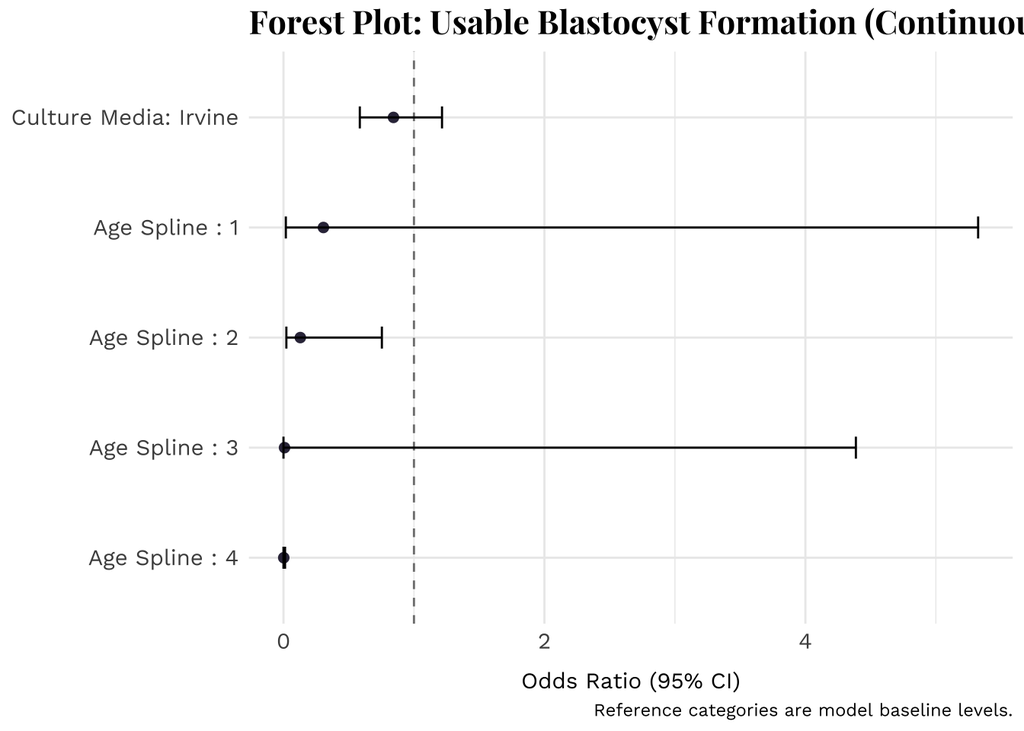

Figure 6. Forest plot of adjusted odds for usable blastocyst formation by culture media (continuous-age spline GEE model).

```r
plot_forest(model_continuous_age, title = "Forest Plot: Usable Blastocyst Formation (Continuous Age Spline Model)", caption = "Reference categories are model baseline levels.")
```

### Euploid Rate

```r
# Prepare data in long format: one row per biopsied embryo
euploid_data <- kpis_ivf |>
  select(patient_id, d1_culture_media, bmi, age, age_group, embryos_biopsied, pgta_euploid) |>
  mutate(
    n_biopsied = as.integer(embryos_biopsied),
    n_euploid = as.integer(pgta_euploid),
    n_euploid = pmax(0L, pmin(n_euploid, n_biopsied))
  ) |>
  filter(!is.na(patient_id)) |>
  filter(!is.na(d1_culture_media)) |>
  filter(!is.na(n_biopsied) & n_biopsied > 0) |>
  filter(!is.na(n_euploid)) |>
  mutate(cycle_row_id = row_number()) |>
  tidyr::uncount(weights = n_biopsied) |>
  group_by(cycle_row_id) |>
  mutate(
    euploid_outcome = as.integer(row_number() <= first(n_euploid))
  ) |>
  ungroup() |>
  mutate(
    d1_culture_media = factor(d1_culture_media),
    age_group = factor(age_group)
  )

# Keep only complete model rows
euploid_model_data <- euploid_data |>
  filter(!is.na(bmi), !is.na(age_group)) |>
  mutate(culture_media = d1_culture_media) |>
  droplevels() |>
  auto_label()

# Guardrails: stop early with useful diagnostics
if (nrow(euploid_model_data) == 0) {
  stop("No rows available for model after filtering for non-missing BMI/oocyte_age_group.")
}
if (dplyr::n_distinct(euploid_model_data$d1_culture_media) < 2) {
  stop("d1_culture_media has <2 levels in model data.")
}
if (dplyr::n_distinct(euploid_model_data$age_group) < 2) {
  stop("oocyte_age_group has <2 levels in model data.")
}

# Fit GEE logistic regression
euploid_model <- geepack::geeglm(
  euploid_outcome ~ culture_media + age_group,
  id = patient_id,
  data = euploid_model_data,
  family = binomial,
  corstr = "exchangeable"
)

# Show model summary
tbl4 <- tbl_regression(euploid_model, exponentiate = TRUE) |>
  modify_caption("**Table 4. Adjusted Odds of Euploidy by Culture Media (GEE Model)**") |>
  modify_footnote(
    estimate ~ "Population-averaged odds ratios from a logistic GEE model with exchangeable working correlation; biopsied embryos clustered within patient (id = patient_id) and robust (sandwich) standard errors used for within-patient correlation."
  )

print(tbl4)
```

**Table 4. Adjusted Odds of Euploidy by Culture Media (GEE Model)**

| **Characteristic** | **OR**<sup>1</sup> | **95% CI** | **p-value** |
| --- | --- | --- | --- |
| Culture Media |  |  |  |
| Global | — | — |  |
| Irvine | 1.18 | 1.04, 1.33 | 0.010 |
| Age Group |  |  |  |
| <35 | — | — |  |
| 35-37 | 0.70 | 0.62, 0.79 | <0.001 |
| 38-40 | 0.43 | 0.37, 0.50 | <0.001 |
| 41-42 | 0.18 | 0.14, 0.23 | <0.001 |
| 43+ | 0.08 | 0.06, 0.12 | <0.001 |

Abbreviations: CI = Confidence Interval, OR = Odds Ratio  
<sup>1</sup> Population-averaged odds ratios from a logistic GEE model with exchangeable working correlation; biopsied embryos clustered within patient (id = patient_id) and robust (sandwich) standard errors used for within-patient correlation.

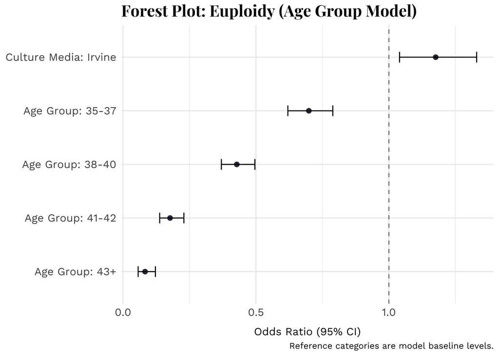

Figure 7. Forest plot of adjusted odds for euploidy by culture media (age-group GEE model).

```r
plot_forest(euploid_model, title = "Forest Plot: Euploidy (Age Group Model)", caption = "Reference categories are model baseline levels.")
```

```r
# Build explicit spline basis terms so they are displayed cleanly in tbl_regression
euploid_model_data_spline <- euploid_model_data |>
  mutate(
    age_spline = splines::ns(age, df = 4),
    age_spline_1 = age_spline[, 1],
    age_spline_2 = age_spline[, 2],
    age_spline_3 = age_spline[, 3],
    age_spline_4 = age_spline[, 4]
  ) |>
  select(-age_spline) |>
  auto_label()

# Fit GEE logistic regression with continuous age, using splines to fit expected non-linear curve
euploid_model_continuous_age <- geepack::geeglm(
  euploid_outcome ~ culture_media + age_spline_1 + age_spline_2 + age_spline_3 + age_spline_4,
  id = patient_id,
  data = euploid_model_data_spline,
  family = binomial,
  corstr = "exchangeable"
)

tbl5 <- tbl_regression(
  euploid_model_continuous_age,
  exponentiate = TRUE,
  include = c(culture_media, age_spline_1, age_spline_2, age_spline_3, age_spline_4),
  label = spline_term_labels
) |>
  modify_caption("**Table 5. Adjusted Odds of Euploidy by Culture Media (GEE Model; age treated as continuous using natural spline terms)**") |>
  modify_footnote(
    estimate ~ "Population-averaged odds ratios from a logistic GEE model with exchangeable working correlation; biopsied embryos clustered within patient (id = patient_id) and robust (sandwich) standard errors used for within-patient correlation."
  )

print(tbl5)
```

**Table 5. Adjusted Odds of Euploidy by Culture Media (GEE Model; age treated as continuous using natural spline terms)**

| **Characteristic** | **OR**<sup>1</sup> | **95% CI** | **p-value** |
| --- | --- | --- | --- |
| Culture Media |  |  |  |
| Global | — | — |  |
| Irvine | 1.16 | 1.03, 1.31 | 0.017 |
| Age (non-linear term 1) | 0.43 | 0.28, 0.65 | <0.001 |
| Age (non-linear term 2) | 0.32 | 0.22, 0.47 | <0.001 |
| Age (non-linear term 3) | 0.02 | 0.01, 0.05 | <0.001 |
| Age (non-linear term 4) | 0.01 | 0.00, 0.02 | <0.001 |

Abbreviations: CI = Confidence Interval, OR = Odds Ratio  
<sup>1</sup> Population-averaged odds ratios from a logistic GEE model with exchangeable working correlation; biopsied embryos clustered within patient (id = patient_id) and robust (sandwich) standard errors used for within-patient correlation.

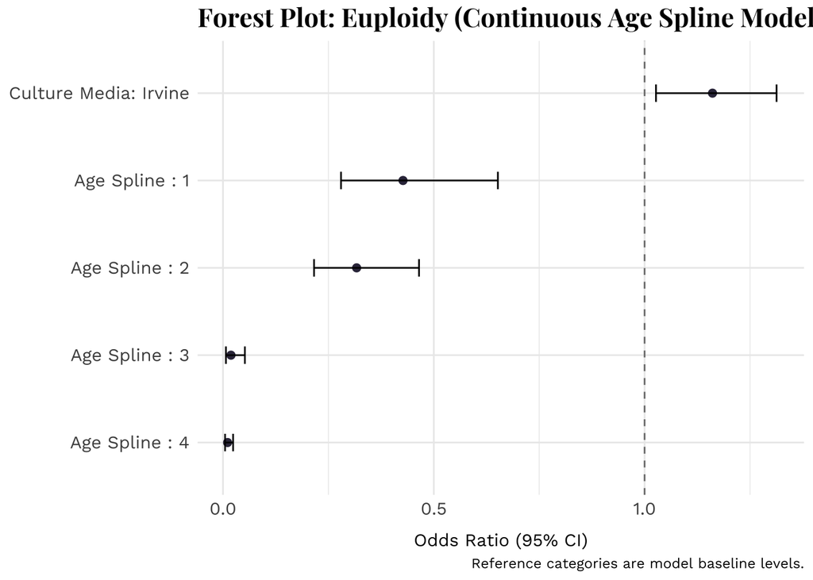

Figure 8. Forest plot of adjusted odds for euploidy by culture media (continuous-age spline GEE model).

```r
plot_forest(euploid_model_continuous_age, title = "Forest Plot: Euploidy (Continuous Age Spline Model)", caption = "Reference categories are model baseline levels.")
```

## Outcomes from Single Euploid Frozen Embryo Transfers

```r
t2_data <- kpis_fet |>
  filter(expansion >= 3) |> # restrict to transfers of blastocysts with at least expansion 3, as these are the ones considered "usable" in the culture outcomes analyses
  select(
    transferred_embryos_d1_culture_media, age, bmi, protocol,
    starts_with("attempt_diagnosis"),
    day_number, expansion,
    icm_grade, troph_grade, #oocyte_age_group,
    prev_attempt_count_euploid_transfers,
    positive_pregnancy_beta_hcg = preg_attempt_outcome,
    positive_pregnancy_gestational_sac = preg_sac
  ) |>
  auto_label()

t2_main <- t2_data |>
  tbl_summary(by = transferred_embryos_d1_culture_media) |>
  add_p(test = list(
    all_categorical() ~ "chisq.test",
    all_continuous() ~ "wilcox.test"
  )) |>
  add_overall() |>
  modify_spanning_header(c(stat_1, stat_2) ~ "**Culture Media**") |>
  bold_labels()

t2_main
```

| **Characteristic** | **Overall** N = 929<sup>1</sup> | **Culture Media** **Global** N = 307<sup>1</sup> | **Culture Media** **Irvine** N = 622<sup>1</sup> | **p-value**<sup>2</sup> |  |
| --- | --- | --- | --- | --- | --- |
| Age | 35.2 (32.4, 38.2) | 35.3 (33.2, 38.8) | 35.0 (32.0, 37.8) |  | 0.006 |
| BMI | 28 (24, 34) | 28 (24, 35) | 27 (24, 33) | 0.3 |  |
| Unknown | 7 | 4 | 3 |  |  |
| Protocol |  |  |  | 0.002 |  |
| Embryo Transfer - Medicated | 303 (33%) | 111 (36%) | 192 (31%) |  |  |
| Embryo Transfer - Medicated Thin Lining | 2 (0.2%) | 1 (0.3%) | 1 (0.2%) |  |  |
| Embryo Transfer - Medicated with Antihistamine | 112 (12%) | 39 (13%) | 73 (12%) |  |  |
| Embryo Transfer - Natural | 30 (3.2%) | 10 (3.3%) | 20 (3.2%) |  |  |
| FET HRT | 101 (11%) | 38 (12%) | 63 (10%) |  |  |
| LED tulip | 4 (0.4%) | 0 (0%) | 4 (0.6%) |  |  |
| Mini Stim | 3 (0.3%) | 0 (0%) | 3 (0.5%) |  |  |
| Modified Natural FET | 160 (17%) | 46 (15%) | 114 (18%) |  |  |
| Natural Cycle FET | 4 (0.4%) | 1 (0.3%) | 3 (0.5%) |  |  |
| Standard FET | 117 (13%) | 19 (6.2%) | 98 (16%) |  |  |
| Standard FET w/patch | 81 (8.7%) | 36 (12%) | 45 (7.2%) |  |  |
| Stim FET with antag w/ AH | 11 (1.2%) | 6 (2.0%) | 5 (0.8%) |  |  |
| Stim FET with lupron w/ AH | 1 (0.1%) | 0 (0%) | 1 (0.2%) |  |  |
| Attempt Diagnosis Male Factor | 189 (20%) | 69 (22%) | 120 (19%) | 0.3 |  |
| Attempt Diagnosis Tubal Factor | 93 (10%) | 31 (10%) | 62 (10.0%) | >0.9 |  |
| Attempt Diagnosis Uterine Factor | 10 (1.1%) | 2 (0.7%) | 8 (1.3%) | 0.6 |  |
| Attempt Diagnosis Ovulation Disorder | 444 (48%) | 157 (51%) | 287 (46%) | 0.2 |  |
| Attempt Diagnosis Pcos | 197 (21%) | 65 (21%) | 132 (21%) | >0.9 |  |
| Attempt Diagnosis Fha | 4 (0.4%) | 2 (0.7%) | 2 (0.3%) | 0.8 |  |
| Attempt Diagnosis Dor | 191 (21%) | 75 (24%) | 116 (19%) | 0.049 |  |
| Attempt Diagnosis Other Ovulation Disorder | 52 (5.6%) | 15 (4.9%) | 37 (5.9%) | 0.6 |  |
| Attempt Diagnosis Gestational Carrier | 2 (0.2%) | 2 (0.7%) | 0 (0%) | 0.2 |  |
| Attempt Diagnosis Freeze all | 15 (1.6%) | 1 (0.3%) | 14 (2.3%) | 0.056 |  |
| Attempt Diagnosis Recurrent Pregnancy Loss | 78 (8.4%) | 20 (6.5%) | 58 (9.3%) | 0.2 |  |
| Attempt Diagnosis PGT | 54 (5.8%) | 18 (5.9%) | 36 (5.8%) | >0.9 |  |
| Attempt Diagnosis Unexplained Infertility | 105 (11%) | 27 (8.8%) | 78 (13%) | 0.11 |  |
| Attempt Diagnosis Other Non Infertile | 43 (4.6%) | 21 (6.8%) | 22 (3.5%) | 0.037 |  |
| Day Number |  |  |  | <0.001 |  |
| 5 | 506 (54%) | 130 (42%) | 376 (60%) |  |  |
| 6 | 409 (44%) | 173 (56%) | 236 (38%) |  |  |
| 7 | 14 (1.5%) | 4 (1.3%) | 10 (1.6%) |  |  |
| Expansion |  |  |  | 0.011 |  |
| 3 | 65 (7.0%) | 13 (4.2%) | 52 (8.4%) |  |  |
| 4 | 747 (80%) | 256 (83%) | 491 (79%) |  |  |
| 5 | 97 (10%) | 27 (8.8%) | 70 (11%) |  |  |
| 6 | 20 (2.2%) | 11 (3.6%) | 9 (1.4%) |  |  |
| ICM Grade |  |  |  | <0.001 |  |
| A | 622 (67%) | 178 (58%) | 444 (71%) |  |  |
| B | 307 (33%) | 129 (42%) | 178 (29%) |  |  |
| Troph Grade |  |  |  | <0.001 |  |
| A | 298 (32%) | 70 (23%) | 228 (37%) |  |  |
| B | 631 (68%) | 237 (77%) | 394 (63%) |  |  |
| Prev Attempt Count Euploid Transfers |  |  |  | 0.6 |  |
| 0 | 649 (70%) | 204 (66%) | 445 (72%) |  |  |
| 1 | 208 (22%) | 77 (25%) | 131 (21%) |  |  |
| 2 | 56 (6.0%) | 21 (6.8%) | 35 (5.6%) |  |  |
| 3 | 12 (1.3%) | 4 (1.3%) | 8 (1.3%) |  |  |
| 4 | 4 (0.4%) | 1 (0.3%) | 3 (0.5%) |  |  |
| Positive Pregnancy Beta Hcg | 651 (70%) | 203 (66%) | 448 (72%) | 0.076 |  |
| Positive Pregnancy Gestational Sac | 522 (57%) | 162 (53%) | 360 (59%) | 0.10 |  |
| Unknown | 15 | 2 | 13 |  |  |

<sup>1</sup> Median (Q1, Q3); n (%)  
<sup>2</sup> Wilcoxon rank sum test; Pearson’s Chi-squared test

### Transfer Outcome Rate Plots by Age and Culture Media

```r
to_binary01 <- function(x) {
  if (is.logical(x)) {
    return(as.integer(x))
  }
  if (is.numeric(x)) {
    return(dplyr::case_when(
      x == 1 ~ 1L,
      x == 0 ~ 0L,
      TRUE ~ NA_integer_
    ))
  }

  x_chr <- tolower(trimws(as.character(x)))
  dplyr::case_when(
    x_chr %in% c("1", "true", "t", "yes", "y", "positive", "pos", "pregnant") ~ 1L,
    x_chr %in% c("0", "false", "f", "no", "n", "negative", "neg", "not pregnant") ~ 0L,
    TRUE ~ NA_integer_
  )
}

transfer_model_data <- kpis_fet |>
  transmute(
    patient_id,
    culture_media = factor(transferred_embryos_d1_culture_media),
    age_group = factor(age_group),
    age,
    day_number, expansion,
    icm_grade, troph_grade,
    prev_attempt_count_euploid_transfers,
    positive_pregnancy_beta_hcg = to_binary01(preg_attempt_outcome),
    positive_pregnancy_gestational_sac = to_binary01(preg_sac)
  )
```

[figure not shown]

Figure 3. Positive beta-hCG rate by age and culture media (single euploid transfer attempts with observed beta-hCG outcomes).

```r
beta_plot_data <- transfer_model_data |>
  filter(!is.na(age), !is.na(positive_pregnancy_beta_hcg)) |>
  mutate(age_year = floor(age)) |>
  group_by(culture_media, age_year) |>
  summarize(
    n_transfers = n(),
    positive_rate = mean(positive_pregnancy_beta_hcg),
    .groups = "drop"
  )

plot3 <- ggplot(beta_plot_data, aes(x = age_year, y = positive_rate, color = culture_media, group = culture_media)) +
  geom_line(linewidth = 1.1) +
  geom_point(aes(size = n_transfers), alpha = 0.8) +
  scale_y_continuous(labels = scales::percent_format(accuracy = 1), limits = c(0, 1)) +
  scale_x_continuous(breaks = scales::pretty_breaks()) +
  scale_size_continuous(name = "Transfers with beta-hCG outcome (N)") +
  labs(
    title = "Positive Beta-hCG Rate by Age and Culture Media",
    subtitle = "Observed positive beta-hCG outcomes among single euploid transfers",
    x = "Age (binned by year)",
    y = "Positive beta-hCG rate",
    color = "Culture media"
  )

add_kb_logo(plot3)
```

[figure not shown]

Figure 4. Positive gestational sac rate by age and culture media (single euploid transfer attempts with observed gestational sac outcomes).

```r
gsac_plot_data <- transfer_model_data |>
  filter(!is.na(age), !is.na(positive_pregnancy_gestational_sac)) |>
  mutate(age_year = floor(age)) |>
  group_by(culture_media, age_year) |>
  summarize(
    n_transfers = n(),
    positive_rate = mean(positive_pregnancy_gestational_sac),
    .groups = "drop"
  )

plot4 <- ggplot(gsac_plot_data, aes(x = age_year, y = positive_rate, color = culture_media, group = culture_media)) +
  geom_line(linewidth = 1.1) +
  geom_point(aes(size = n_transfers), alpha = 0.8) +
  scale_y_continuous(labels = scales::percent_format(accuracy = 1), limits = c(0, 1)) +
  scale_x_continuous(breaks = scales::pretty_breaks()) +
  scale_size_continuous(name = "Transfers with gestational sac outcome (N)") +
  labs(
    title = "Positive Gestational Sac Rate by Age and Culture Media",
    subtitle = "Observed positive gestational sac outcomes among single euploid transfers",
    x = "Age (binned by year)",
    y = "Positive gestational sac rate",
    color = "Culture media"
  )

add_kb_logo(plot4)
```

### GEE Logistic Regression Models for Transfer Outcomes

```r
beta_model_data <- transfer_model_data |>
  select(day_number, expansion, icm_grade, troph_grade, prev_attempt_count_euploid_transfers,
    patient_id, age, age_group, culture_media, positive_pregnancy_beta_hcg) |>
  drop_na() |>
  droplevels() |>
  auto_label()

if (nrow(beta_model_data) == 0) {
  stop("No rows available for positive beta-hCG model after filtering.")
}
if (dplyr::n_distinct(beta_model_data$culture_media) < 2) {
  stop("culture_media has <2 levels in positive beta-hCG model data.")
}
if (dplyr::n_distinct(beta_model_data$age_group) < 2) {
  stop("age_group has <2 levels in positive beta-hCG model data.")
}

beta_model <- geepack::geeglm(
  positive_pregnancy_beta_hcg ~ culture_media + age_group + day_number + expansion + icm_grade + troph_grade + prev_attempt_count_euploid_transfers,
  id = patient_id,
  data = beta_model_data,
  family = binomial,
  corstr = "exchangeable"
)

tbl6 <- tbl_regression(beta_model, exponentiate = TRUE) |>
  modify_caption("**Table 6. Adjusted Odds of Positive Beta-hCG by Culture Media (GEE Model)**") |>
  modify_footnote(
    estimate ~ "Population-averaged odds ratios from a logistic GEE model with exchangeable working correlation; transfer attempts clustered within patient (id = patient_id) and robust (sandwich) standard errors used for within-patient correlation."
  )

print(tbl6)
```

**Table 6. Adjusted Odds of Positive Beta-hCG by Culture Media (GEE Model)**

| **Characteristic** | **OR**<sup>1</sup> | **95% CI** | **p-value** |
| --- | --- | --- | --- |
| Culture Media |  |  |  |
| Global | — | — |  |
| Irvine | 1.17 | 0.86, 1.58 | 0.3 |
| Age Group |  |  |  |
| <35 | — | — |  |
| 35-37 | 0.73 | 0.52, 1.04 | 0.085 |
| 38-40 | 0.60 | 0.41, 0.88 | 0.009 |
| 41-42 | 0.74 | 0.37, 1.47 | 0.4 |
| 43+ | 0.65 | 0.28, 1.54 | 0.3 |
| Day Number |  |  |  |
| 5 | — | — |  |
| 6 | 0.88 | 0.64, 1.22 | 0.4 |
| 7 | 0.24 | 0.08, 0.75 | 0.014 |
| Expansion |  |  |  |
| 3 | — | — |  |
| 4 | 1.52 | 0.87, 2.68 | 0.14 |
| 5 | 2.15 | 1.03, 4.45 | 0.040 |
| 6 | 1.29 | 0.44, 3.81 | 0.6 |
| ICM Grade |  |  |  |
| A | — | — |  |
| B | 0.84 | 0.61, 1.15 | 0.3 |
| Troph Grade |  |  |  |
| A | — | — |  |
| B | 0.68 | 0.48, 0.98 | 0.036 |
| Prev Attempt Count Euploid Transfers | 0.89 | 0.73, 1.08 | 0.2 |

Abbreviations: CI = Confidence Interval, OR = Odds Ratio  
<sup>1</sup> Population-averaged odds ratios from a logistic GEE model with exchangeable working correlation; transfer attempts clustered within patient (id = patient_id) and robust (sandwich) standard errors used for within-patient correlation.

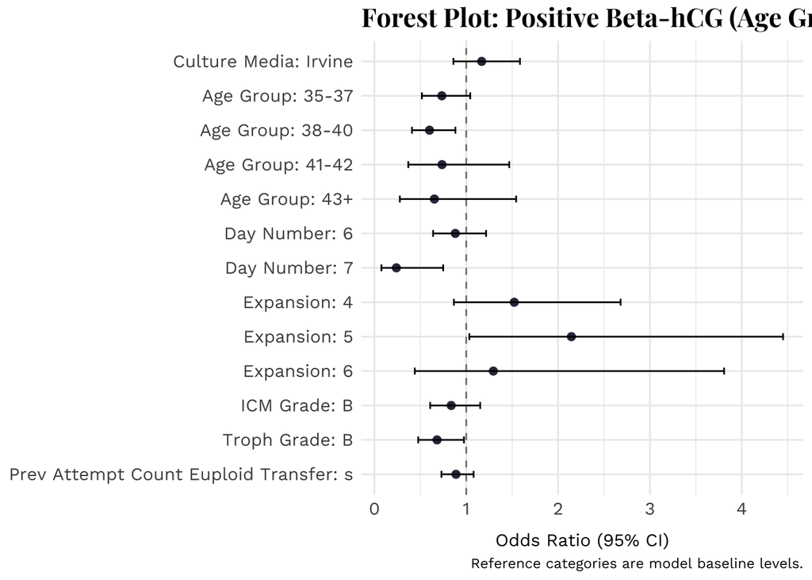

Figure 9. Forest plot of adjusted odds for positive beta-hCG by culture media (age-group GEE model).

```r
plot_forest(beta_model, title = "Forest Plot: Positive Beta-hCG (Age Group Model)", caption = "Reference categories are model baseline levels.")
```

```r
beta_model_data_spline <- beta_model_data |>
  mutate(
    age_spline = splines::ns(age, df = 4),
    age_spline_1 = age_spline[, 1],
    age_spline_2 = age_spline[, 2],
    age_spline_3 = age_spline[, 3],
    age_spline_4 = age_spline[, 4]
  ) |>
  select(-age_spline)

beta_model_continuous_age <- geepack::geeglm(
  positive_pregnancy_beta_hcg ~ culture_media + age_spline_1 + age_spline_2 + age_spline_3 + age_spline_4 + day_number + expansion + icm_grade + troph_grade + prev_attempt_count_euploid_transfers,
  id = patient_id,
  data = beta_model_data_spline,
  family = binomial,
  corstr = "exchangeable"
)

tbl7 <- tbl_regression(
  beta_model_continuous_age,
  exponentiate = TRUE,
  include = c(culture_media, age_spline_1, age_spline_2, age_spline_3, age_spline_4, day_number, expansion, icm_grade, troph_grade, prev_attempt_count_euploid_transfers),
  label = spline_term_labels
) |>
  modify_caption("**Table 7. Adjusted Odds of Positive Beta-hCG by Culture Media (GEE Model; age treated as continuous using natural spline terms)**") |>
  modify_footnote(
    estimate ~ "Population-averaged odds ratios from a logistic GEE model with exchangeable working correlation; transfer attempts clustered within patient (id = patient_id) and robust (sandwich) standard errors used for within-patient correlation."
  )

print(tbl7)
```

**Table 7. Adjusted Odds of Positive Beta-hCG by Culture Media (GEE Model; age treated as continuous using natural spline terms)**

| **Characteristic** | **OR**<sup>1</sup> | **95% CI** | **p-value** |
| --- | --- | --- | --- |
| Culture Media |  |  |  |
| Global | — | — |  |
| Irvine | 1.15 | 0.85, 1.56 | 0.4 |
| Age (non-linear term 1) | 0.26 | 0.04, 1.74 | 0.2 |
| Age (non-linear term 2) | 0.24 | 0.06, 0.92 | 0.037 |
| Age (non-linear term 3) | 0.10 | 0.00, 7.62 | 0.3 |
| Age (non-linear term 4) | 0.44 | 0.11, 1.68 | 0.2 |
| Day Number |  |  |  |
| 5 | — | — |  |
| 6 | 0.90 | 0.65, 1.24 | 0.5 |
| 7 | 0.27 | 0.09, 0.82 | 0.021 |
| Expansion |  |  |  |
| 3 | — | — |  |
| 4 | 1.52 | 0.85, 2.70 | 0.2 |
| 5 | 2.14 | 1.02, 4.47 | 0.044 |
| 6 | 1.28 | 0.43, 3.78 | 0.7 |
| ICM Grade |  |  |  |
| A | — | — |  |
| B | 0.82 | 0.60, 1.13 | 0.2 |
| Troph Grade |  |  |  |
| A | — | — |  |
| B | 0.71 | 0.49, 1.01 | 0.059 |
| Prev Attempt Count Euploid Transfers | 0.89 | 0.73, 1.09 | 0.3 |

Abbreviations: CI = Confidence Interval, OR = Odds Ratio  
<sup>1</sup> Population-averaged odds ratios from a logistic GEE model with exchangeable working correlation; transfer attempts clustered within patient (id = patient_id) and robust (sandwich) standard errors used for within-patient correlation.

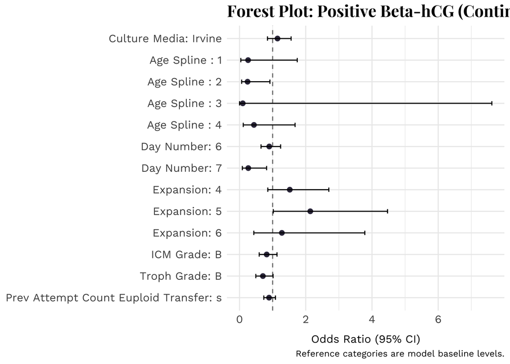

Figure 10. Forest plot of adjusted odds for positive beta-hCG by culture media (continuous-age spline GEE model).

```r
plot_forest(beta_model_continuous_age, title = "Forest Plot: Positive Beta-hCG (Continuous Age Spline Model)", caption = "Reference categories are model baseline levels.")
```

```r
gsac_model_data <- transfer_model_data |>
  filter(!is.na(patient_id), !is.na(culture_media), !is.na(age_group), !is.na(positive_pregnancy_gestational_sac)) |>
  droplevels() |>
  auto_label()

if (nrow(gsac_model_data) == 0) {
  stop("No rows available for positive gestational sac model after filtering.")
}
if (dplyr::n_distinct(gsac_model_data$culture_media) < 2) {
  stop("culture_media has <2 levels in positive gestational sac model data.")
}
if (dplyr::n_distinct(gsac_model_data$age_group) < 2) {
  stop("age_group has <2 levels in positive gestational sac model data.")
}

gsac_model <- geepack::geeglm(
  positive_pregnancy_gestational_sac ~ culture_media + age_group + day_number + expansion + icm_grade + troph_grade + prev_attempt_count_euploid_transfers,
  id = patient_id,
  data = gsac_model_data,
  family = binomial,
  corstr = "exchangeable"
)

tbl8 <- tbl_regression(gsac_model, exponentiate = TRUE) |>
  modify_caption("**Table 8. Adjusted Odds of Positive Gestational Sac by Culture Media (GEE Model)**") |>
  modify_footnote(
    estimate ~ "Population-averaged odds ratios from a logistic GEE model with exchangeable working correlation; transfer attempts clustered within patient (id = patient_id) and robust (sandwich) standard errors used for within-patient correlation."
  )

print(tbl8)
```

**Table 8. Adjusted Odds of Positive Gestational Sac by Culture Media (GEE Model)**

| **Characteristic** | **OR**<sup>1</sup> | **95% CI** | **p-value** |
| --- | --- | --- | --- |
| Culture Media |  |  |  |
| Global | — | — |  |
| Irvine | 1.09 | 0.81, 1.46 | 0.6 |
| Age Group |  |  |  |
| <35 | — | — |  |
| 35-37 | 0.89 | 0.64, 1.24 | 0.5 |
| 38-40 | 0.70 | 0.48, 1.01 | 0.058 |
| 41-42 | 0.57 | 0.30, 1.08 | 0.086 |
| 43+ | 0.68 | 0.29, 1.64 | 0.4 |
| Day Number |  |  |  |
| 5 | — | — |  |
| 6 | 0.90 | 0.67, 1.23 | 0.5 |
| 7 | 0.29 | 0.08, 1.04 | 0.058 |
| Expansion |  |  |  |
| 3 | — | — |  |
| 4 | 1.40 | 0.82, 2.39 | 0.2 |
| 5 | 1.32 | 0.68, 2.58 | 0.4 |
| 6 | 0.90 | 0.32, 2.56 | 0.8 |
| ICM Grade |  |  |  |
| A | — | — |  |
| B | 0.62 | 0.46, 0.83 | 0.002 |
| Troph Grade |  |  |  |
| A | — | — |  |
| B | 0.68 | 0.49, 0.94 | 0.020 |
| Prev Attempt Count Euploid Transfers | 0.81 | 0.67, 0.98 | 0.030 |

Abbreviations: CI = Confidence Interval, OR = Odds Ratio  
<sup>1</sup> Population-averaged odds ratios from a logistic GEE model with exchangeable working correlation; transfer attempts clustered within patient (id = patient_id) and robust (sandwich) standard errors used for within-patient correlation.

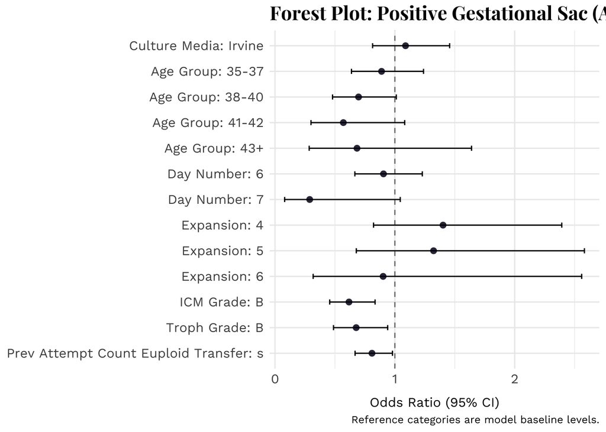

Figure 11. Forest plot of adjusted odds for positive gestational sac by culture media (age-group GEE model).

```r
plot_forest(gsac_model, title = "Forest Plot: Positive Gestational Sac (Age Group Model)", caption = "Reference categories are model baseline levels.")
```

```r
gsac_model_data_spline <- gsac_model_data |>
  mutate(
    age_spline = splines::ns(age, df = 4),
    age_spline_1 = age_spline[, 1],
    age_spline_2 = age_spline[, 2],
    age_spline_3 = age_spline[, 3],
    age_spline_4 = age_spline[, 4]
  ) |>
  select(-age_spline)

gsac_model_continuous_age <- geepack::geeglm(
  positive_pregnancy_gestational_sac ~ culture_media + age_spline_1 + age_spline_2 + age_spline_3 + age_spline_4 + day_number + expansion + icm_grade + troph_grade + prev_attempt_count_euploid_transfers,
  id = patient_id,
  data = gsac_model_data_spline,
  family = binomial,
  corstr = "exchangeable"
)

tbl9 <- tbl_regression(
  gsac_model_continuous_age,
  exponentiate = TRUE,
  include = c(culture_media, age_spline_1, age_spline_2, age_spline_3, age_spline_4, day_number, expansion, icm_grade, troph_grade, prev_attempt_count_euploid_transfers),
  label = spline_term_labels
) |>
  modify_caption("**Table 9. Adjusted Odds of Positive Gestational Sac by Culture Media (GEE Model; age treated as continuous using natural spline terms)**") |>
  modify_footnote(
    estimate ~ "Population-averaged odds ratios from a logistic GEE model with exchangeable working correlation; transfer attempts clustered within patient (id = patient_id) and robust (sandwich) standard errors used for within-patient correlation."
  )

print(tbl9)
```

**Table 9. Adjusted Odds of Positive Gestational Sac by Culture Media (GEE Model; age treated as continuous using natural spline terms)**

| **Characteristic** | **OR**<sup>1</sup> | **95% CI** | **p-value** |
| --- | --- | --- | --- |
| Culture Media |  |  |  |
| Global | — | — |  |
| Irvine | 1.06 | 0.79, 1.42 | 0.7 |
| Age (non-linear term 1) | 0.26 | 0.05, 1.30 | 0.10 |
| Age (non-linear term 2) | 0.24 | 0.07, 0.77 | 0.017 |
| Age (non-linear term 3) | 0.05 | 0.00, 2.20 | 0.12 |
| Age (non-linear term 4) | 0.45 | 0.12, 1.63 | 0.2 |
| Day Number |  |  |  |
| 5 | — | — |  |
| 6 | 0.92 | 0.67, 1.25 | 0.6 |
| 7 | 0.31 | 0.09, 1.08 | 0.066 |
| Expansion |  |  |  |
| 3 | — | — |  |
| 4 | 1.39 | 0.81, 2.38 | 0.2 |
| 5 | 1.32 | 0.67, 2.60 | 0.4 |
| 6 | 0.91 | 0.32, 2.59 | 0.9 |
| ICM Grade |  |  |  |
| A | — | — |  |
| B | 0.61 | 0.45, 0.82 | 0.001 |
| Troph Grade |  |  |  |
| A | — | — |  |
| B | 0.70 | 0.50, 0.97 | 0.034 |
| Prev Attempt Count Euploid Transfers | 0.81 | 0.67, 0.98 | 0.033 |

Abbreviations: CI = Confidence Interval, OR = Odds Ratio  
<sup>1</sup> Population-averaged odds ratios from a logistic GEE model with exchangeable working correlation; transfer attempts clustered within patient (id = patient_id) and robust (sandwich) standard errors used for within-patient correlation.

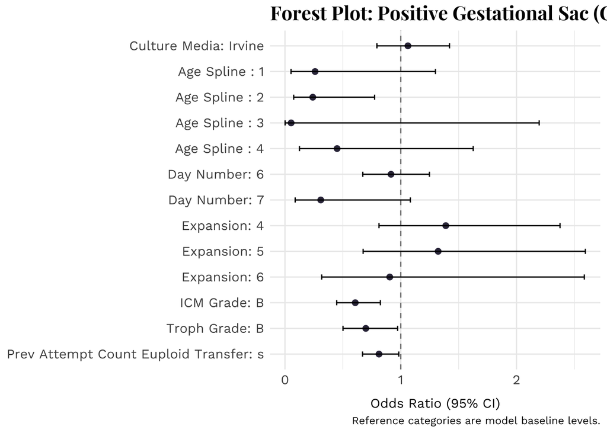

Figure 12. Forest plot of adjusted odds for positive gestational sac by culture media (continuous-age spline GEE model).

```r
plot_forest(gsac_model_continuous_age, title = "Forest Plot: Positive Gestational Sac (Continuous Age Spline Model)", caption = "Reference categories are model baseline levels.")
```